# Optimal Treatment Analysis

## Outcome Variable

**Outcome Variable:** whz

## Predictor Variables

**Intervention Variable:** hdlvry

**Adjustment Set:**

- arm
- sex
- W_mage
- meducyrs
- feducyrs
- hhwealth_quart
- single
- W_nrooms
- brthmon
- W_parity
- impsan
- delta_W_mage
- delta_meducyrs
- delta_feducyrs
- delta_hhwealth_quart
- delta_single
- delta_W_nrooms
- delta_brthmon
- delta_W_parity
- delta_impsan

## Stratifying Variables

The analysis was stratified on these variable(s):

- agecat
- studyid
- country

## Data Summary

| agecat | studyid | country | hdlvry | n_cell | n |
| --- | --- | --- | --- | --- | --- |
| Birth | ki1000108-CMC-V-BCS-2002 | INDIA | 0 | 86 | 86 |
| Birth | ki1000108-CMC-V-BCS-2002 | INDIA | 1 | 0 | 86 |
| Birth | ki1000108-IRC | INDIA | 0 | 337 | 343 |
| Birth | ki1000108-IRC | INDIA | 1 | 6 | 343 |
| Birth | ki1000109-EE | PAKISTAN | 0 | 120 | 175 |
| Birth | ki1000109-EE | PAKISTAN | 1 | 55 | 175 |
| Birth | ki1000304b-SAS-CompFeed | INDIA | 0 | 108 | 957 |
| Birth | ki1000304b-SAS-CompFeed | INDIA | 1 | 849 | 957 |
| Birth | ki1017093b-PROVIDE | BANGLADESH | 0 | 387 | 532 |
| Birth | ki1017093b-PROVIDE | BANGLADESH | 1 | 145 | 532 |
| Birth | ki1017093c-NIH-Crypto | BANGLADESH | 0 | 548 | 707 |
| Birth | ki1017093c-NIH-Crypto | BANGLADESH | 1 | 159 | 707 |
| Birth | ki1113344-GMS-Nepal | NEPAL | 0 | 143 | 596 |
| Birth | ki1113344-GMS-Nepal | NEPAL | 1 | 453 | 596 |
| Birth | ki1135781-COHORTS | INDIA | 0 | 2763 | 4389 |
| Birth | ki1135781-COHORTS | INDIA | 1 | 1626 | 4389 |
| Birth | kiGH5241-JiVitA-3 | BANGLADESH | 0 | 38 | 307 |
| Birth | kiGH5241-JiVitA-3 | BANGLADESH | 1 | 269 | 307 |
| Birth | kiGH5241-JiVitA-4 | BANGLADESH | 0 | 500 | 2384 |
| Birth | kiGH5241-JiVitA-4 | BANGLADESH | 1 | 1884 | 2384 |
| 6 months | ki1000108-CMC-V-BCS-2002 | INDIA | 0 | 357 | 365 |
| 6 months | ki1000108-CMC-V-BCS-2002 | INDIA | 1 | 8 | 365 |
| 6 months | ki1000108-IRC | INDIA | 0 | 400 | 408 |
| 6 months | ki1000108-IRC | INDIA | 1 | 8 | 408 |
| 6 months | ki1000109-EE | PAKISTAN | 0 | 252 | 373 |
| 6 months | ki1000109-EE | PAKISTAN | 1 | 121 | 373 |
| 6 months | ki1000304b-SAS-CompFeed | INDIA | 0 | 147 | 1088 |
| 6 months | ki1000304b-SAS-CompFeed | INDIA | 1 | 941 | 1088 |
| 6 months | ki1000304b-SAS-FoodSuppl | INDIA | 0 | 76 | 380 |
| 6 months | ki1000304b-SAS-FoodSuppl | INDIA | 1 | 304 | 380 |
| 6 months | ki1017093b-PROVIDE | BANGLADESH | 0 | 450 | 603 |
| 6 months | ki1017093b-PROVIDE | BANGLADESH | 1 | 153 | 603 |
| 6 months | ki1017093c-NIH-Crypto | BANGLADESH | 0 | 554 | 715 |
| 6 months | ki1017093c-NIH-Crypto | BANGLADESH | 1 | 161 | 715 |
| 6 months | ki1066203-TanzaniaChild2 | TANZANIA, UNITED REPUBLIC OF | 0 | 1888 | 1920 |
| 6 months | ki1066203-TanzaniaChild2 | TANZANIA, UNITED REPUBLIC OF | 1 | 32 | 1920 |
| 6 months | ki1113344-GMS-Nepal | NEPAL | 0 | 129 | 528 |
| 6 months | ki1113344-GMS-Nepal | NEPAL | 1 | 399 | 528 |
| 6 months | ki1135781-COHORTS | INDIA | 0 | 2896 | 4694 |
| 6 months | ki1135781-COHORTS | INDIA | 1 | 1798 | 4694 |
| 6 months | kiGH5241-JiVitA-3 | BANGLADESH | 0 | 39 | 334 |
| 6 months | kiGH5241-JiVitA-3 | BANGLADESH | 1 | 295 | 334 |
| 6 months | kiGH5241-JiVitA-4 | BANGLADESH | 0 | 1082 | 4042 |
| 6 months | kiGH5241-JiVitA-4 | BANGLADESH | 1 | 2960 | 4042 |
| 24 months | ki1000108-CMC-V-BCS-2002 | INDIA | 0 | 361 | 369 |
| 24 months | ki1000108-CMC-V-BCS-2002 | INDIA | 1 | 8 | 369 |
| 24 months | ki1000108-IRC | INDIA | 0 | 401 | 409 |
| 24 months | ki1000108-IRC | INDIA | 1 | 8 | 409 |
| 24 months | ki1000109-EE | PAKISTAN | 0 | 112 | 167 |
| 24 months | ki1000109-EE | PAKISTAN | 1 | 55 | 167 |
| 24 months | ki1017093b-PROVIDE | BANGLADESH | 0 | 433 | 579 |
| 24 months | ki1017093b-PROVIDE | BANGLADESH | 1 | 146 | 579 |
| 24 months | ki1017093c-NIH-Crypto | BANGLADESH | 0 | 391 | 514 |
| 24 months | ki1017093c-NIH-Crypto | BANGLADESH | 1 | 123 | 514 |
| 24 months | ki1066203-TanzaniaChild2 | TANZANIA, UNITED REPUBLIC OF | 0 | 6 | 6 |
| 24 months | ki1066203-TanzaniaChild2 | TANZANIA, UNITED REPUBLIC OF | 1 | 0 | 6 |
| 24 months | ki1113344-GMS-Nepal | NEPAL | 0 | 118 | 455 |
| 24 months | ki1113344-GMS-Nepal | NEPAL | 1 | 337 | 455 |
| 24 months | ki1135781-COHORTS | INDIA | 0 | 2214 | 3533 |
| 24 months | ki1135781-COHORTS | INDIA | 1 | 1319 | 3533 |
| 24 months | kiGH5241-JiVitA-3 | BANGLADESH | 0 | 34 | 289 |
| 24 months | kiGH5241-JiVitA-3 | BANGLADESH | 1 | 255 | 289 |
| 24 months | kiGH5241-JiVitA-4 | BANGLADESH | 0 | 1032 | 3993 |
| 24 months | kiGH5241-JiVitA-4 | BANGLADESH | 1 | 2961 | 3993 |

The following strata were considered:

- agecat: 24 months, studyid: ki1000108-CMC-V-BCS-2002, country: INDIA
- agecat: 24 months, studyid: ki1000108-IRC, country: INDIA
- agecat: 24 months, studyid: ki1000109-EE, country: PAKISTAN
- agecat: 24 months, studyid: ki1017093b-PROVIDE, country: BANGLADESH
- agecat: 24 months, studyid: ki1017093c-NIH-Crypto, country: BANGLADESH
- agecat: 24 months, studyid: ki1066203-TanzaniaChild2, country: TANZANIA, UNITED REPUBLIC OF
- agecat: 24 months, studyid: ki1113344-GMS-Nepal, country: NEPAL
- agecat: 24 months, studyid: ki1135781-COHORTS, country: INDIA
- agecat: 24 months, studyid: kiGH5241-JiVitA-3, country: BANGLADESH
- agecat: 24 months, studyid: kiGH5241-JiVitA-4, country: BANGLADESH
- agecat: 6 months, studyid: ki1000108-CMC-V-BCS-2002, country: INDIA
- agecat: 6 months, studyid: ki1000108-IRC, country: INDIA
- agecat: 6 months, studyid: ki1000109-EE, country: PAKISTAN
- agecat: 6 months, studyid: ki1000304b-SAS-CompFeed, country: INDIA
- agecat: 6 months, studyid: ki1000304b-SAS-FoodSuppl, country: INDIA
- agecat: 6 months, studyid: ki1017093b-PROVIDE, country: BANGLADESH
- agecat: 6 months, studyid: ki1017093c-NIH-Crypto, country: BANGLADESH
- agecat: 6 months, studyid: ki1066203-TanzaniaChild2, country: TANZANIA, UNITED REPUBLIC OF
- agecat: 6 months, studyid: ki1113344-GMS-Nepal, country: NEPAL
- agecat: 6 months, studyid: ki1135781-COHORTS, country: INDIA
- agecat: 6 months, studyid: kiGH5241-JiVitA-3, country: BANGLADESH
- agecat: 6 months, studyid: kiGH5241-JiVitA-4, country: BANGLADESH
- agecat: Birth, studyid: ki1000108-CMC-V-BCS-2002, country: INDIA
- agecat: Birth, studyid: ki1000108-IRC, country: INDIA
- agecat: Birth, studyid: ki1000109-EE, country: PAKISTAN
- agecat: Birth, studyid: ki1000304b-SAS-CompFeed, country: INDIA
- agecat: Birth, studyid: ki1017093b-PROVIDE, country: BANGLADESH
- agecat: Birth, studyid: ki1017093c-NIH-Crypto, country: BANGLADESH
- agecat: Birth, studyid: ki1113344-GMS-Nepal, country: NEPAL
- agecat: Birth, studyid: ki1135781-COHORTS, country: INDIA
- agecat: Birth, studyid: kiGH5241-JiVitA-3, country: BANGLADESH
- agecat: Birth, studyid: kiGH5241-JiVitA-4, country: BANGLADESH

### Dropped Strata

Some strata were dropped due to rare outcomes:

- agecat: Birth, studyid: ki1000108-CMC-V-BCS-2002, country: INDIA
- agecat: 24 months, studyid: ki1066203-TanzaniaChild2, country: TANZANIA, UNITED REPUBLIC OF

## Methods Detail

We’re interested in the causal parameters $E[Y_a]$ for all values of $a \in \mathcal{A}$. These parameters represent the mean outcome if, possibly contrary to fact, we intervened to set all units to have $A=a$. Under the randomization and positivity assumptions, these are identified by the statistical parameters $\psi_a=E_W[E_{Y|A,W}(Y|A=a,W)]$. In addition, we’re interested in the mean of $Y$, $E[Y]$ under no intervention (the observed mean). We will estimate these parameters by using SuperLearner to fit the relevant likelihood factors – $E_{Y|A,W}(Y|A=a,W)$ and $p(A=a|W)$, and then updating our likelihood fit using a joint TMLE.

For unadjusted analyses ($W=\{\}$), initial likelihoods were estimated using Lrnr_glm to estimate the simple $E(Y|A)$ and Lrnr_mean to estimate $p(A)$. For adjusted analyses, a small library containing Lrnr_glmnet, Lrnr_xgboost, and Lrnr_mean was used.

# Results Detail

## Results Plots

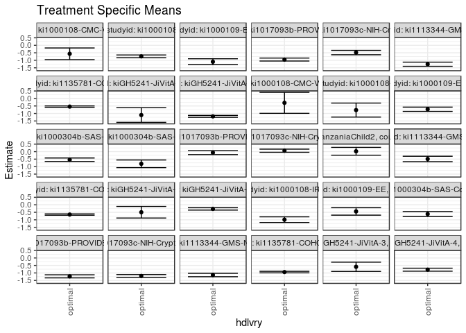

## Results Table

### Parameter: TSM

| agecat | studyid | country | intervention_level | baseline_level | estimate | ci_lower | ci_upper |
| --- | --- | --- | --- | --- | --- | --- | --- |
| Birth | ki1000108-IRC | INDIA | optimal | observed | -0.9919424 | -1.1805471 | -0.8033377 |
| Birth | ki1000109-EE | PAKISTAN | optimal | observed | -0.4426359 | -0.6907778 | -0.1944940 |
| Birth | ki1000304b-SAS-CompFeed | INDIA | optimal | observed | -0.6156644 | -0.7805488 | -0.4507799 |
| Birth | ki1017093b-PROVIDE | BANGLADESH | optimal | observed | -1.2254819 | -1.3283137 | -1.1226501 |
| Birth | ki1017093c-NIH-Crypto | BANGLADESH | optimal | observed | -1.2014671 | -1.2952103 | -1.1077238 |
| Birth | ki1113344-GMS-Nepal | NEPAL | optimal | observed | -1.1374206 | -1.2525952 | -1.0222461 |
| Birth | ki1135781-COHORTS | INDIA | optimal | observed | -0.9414779 | -0.9928764 | -0.8900794 |
| Birth | kiGH5241-JiVitA-3 | BANGLADESH | optimal | observed | -0.5894722 | -0.8974146 | -0.2815299 |
| Birth | kiGH5241-JiVitA-4 | BANGLADESH | optimal | observed | -0.7825433 | -0.8832597 | -0.6818270 |
| 6 months | ki1000108-CMC-V-BCS-2002 | INDIA | optimal | observed | -0.2916545 | -0.9922325 | 0.4089235 |
| 6 months | ki1000108-IRC | INDIA | optimal | observed | -0.7743971 | -1.2420099 | -0.3067843 |
| 6 months | ki1000109-EE | PAKISTAN | optimal | observed | -0.7197637 | -0.8624729 | -0.5770544 |
| 6 months | ki1000304b-SAS-CompFeed | INDIA | optimal | observed | -0.5405186 | -0.6567042 | -0.4243331 |
| 6 months | ki1000304b-SAS-FoodSuppl | INDIA | optimal | observed | -0.8114064 | -1.0664421 | -0.5563706 |
| 6 months | ki1017093b-PROVIDE | BANGLADESH | optimal | observed | -0.0671811 | -0.1986330 | 0.0642708 |
| 6 months | ki1017093c-NIH-Crypto | BANGLADESH | optimal | observed | 0.0612680 | -0.0434686 | 0.1660046 |
| 6 months | ki1066203-TanzaniaChild2 | TANZANIA, UNITED REPUBLIC OF | optimal | observed | 0.0237860 | -0.2364977 | 0.2840697 |
| 6 months | ki1113344-GMS-Nepal | NEPAL | optimal | observed | -0.4887695 | -0.6708912 | -0.3066477 |
| 6 months | ki1135781-COHORTS | INDIA | optimal | observed | -0.6501882 | -0.6951747 | -0.6052018 |
| 6 months | kiGH5241-JiVitA-3 | BANGLADESH | optimal | observed | -0.4963351 | -0.8823102 | -0.1103601 |
| 6 months | kiGH5241-JiVitA-4 | BANGLADESH | optimal | observed | -0.2735957 | -0.3527000 | -0.1944913 |
| 24 months | ki1000108-CMC-V-BCS-2002 | INDIA | optimal | observed | -0.5661140 | -0.9551349 | -0.1770931 |
| 24 months | ki1000108-IRC | INDIA | optimal | observed | -0.7383450 | -0.8311775 | -0.6455125 |
| 24 months | ki1000109-EE | PAKISTAN | optimal | observed | -1.0963445 | -1.2942837 | -0.8984053 |
| 24 months | ki1017093b-PROVIDE | BANGLADESH | optimal | observed | -0.9498475 | -1.0492699 | -0.8504250 |
| 24 months | ki1017093c-NIH-Crypto | BANGLADESH | optimal | observed | -0.4842383 | -0.6308412 | -0.3376353 |
| 24 months | ki1113344-GMS-Nepal | NEPAL | optimal | observed | -1.2617351 | -1.4005155 | -1.1229546 |
| 24 months | ki1135781-COHORTS | INDIA | optimal | observed | -0.5422008 | -0.5865671 | -0.4978345 |
| 24 months | kiGH5241-JiVitA-3 | BANGLADESH | optimal | observed | -1.1046947 | -1.5949097 | -0.6144797 |
| 24 months | kiGH5241-JiVitA-4 | BANGLADESH | optimal | observed | -1.1933617 | -1.2578349 | -1.1288885 |

### Parameter: E(Y)

| agecat | studyid | country | intervention_level | baseline_level | estimate | ci_lower | ci_upper |
| --- | --- | --- | --- | --- | --- | --- | --- |
| Birth | ki1000108-IRC | INDIA | observed | observed | -1.0105831 | -1.1973019 | -0.8238643 |
| Birth | ki1000109-EE | PAKISTAN | observed | observed | -0.3410000 | -0.5302198 | -0.1517802 |
| Birth | ki1000304b-SAS-CompFeed | INDIA | observed | observed | -0.6570846 | -0.8496671 | -0.4645022 |
| Birth | ki1017093b-PROVIDE | BANGLADESH | observed | observed | -1.2984586 | -1.3752758 | -1.2216415 |
| Birth | ki1017093c-NIH-Crypto | BANGLADESH | observed | observed | -1.2441513 | -1.3281130 | -1.1601897 |
| Birth | ki1113344-GMS-Nepal | NEPAL | observed | observed | -1.1277349 | -1.2174865 | -1.0379833 |
| Birth | ki1135781-COHORTS | INDIA | observed | observed | -0.9755867 | -1.0106993 | -0.9404741 |
| Birth | kiGH5241-JiVitA-3 | BANGLADESH | observed | observed | -0.8643648 | -0.9709313 | -0.7577983 |
| Birth | kiGH5241-JiVitA-4 | BANGLADESH | observed | observed | -0.6907341 | -0.7437042 | -0.6377640 |
| 6 months | ki1000108-CMC-V-BCS-2002 | INDIA | observed | observed | -0.5045068 | -0.6566169 | -0.3523968 |
| 6 months | ki1000108-IRC | INDIA | observed | observed | -0.5989297 | -0.7344491 | -0.4634104 |
| 6 months | ki1000109-EE | PAKISTAN | observed | observed | -0.7695800 | -0.8839306 | -0.6552294 |
| 6 months | ki1000304b-SAS-CompFeed | INDIA | observed | observed | -0.6734421 | -0.8121314 | -0.5347528 |
| 6 months | ki1000304b-SAS-FoodSuppl | INDIA | observed | observed | -1.0121579 | -1.1280429 | -0.8962729 |
| 6 months | ki1017093b-PROVIDE | BANGLADESH | observed | observed | -0.1990907 | -0.2817968 | -0.1163845 |
| 6 months | ki1017093c-NIH-Crypto | BANGLADESH | observed | observed | 0.0297622 | -0.0491685 | 0.1086930 |
| 6 months | ki1066203-TanzaniaChild2 | TANZANIA, UNITED REPUBLIC OF | observed | observed | 0.0688763 | 0.0147308 | 0.1230218 |
| 6 months | ki1113344-GMS-Nepal | NEPAL | observed | observed | -0.5992551 | -0.6878945 | -0.5106156 |
| 6 months | ki1135781-COHORTS | INDIA | observed | observed | -0.7160077 | -0.7492815 | -0.6827338 |
| 6 months | kiGH5241-JiVitA-3 | BANGLADESH | observed | observed | -0.6044910 | -0.7122040 | -0.4967781 |
| 6 months | kiGH5241-JiVitA-4 | BANGLADESH | observed | observed | -0.3760651 | -0.4191017 | -0.3330285 |
| 24 months | ki1000108-CMC-V-BCS-2002 | INDIA | observed | observed | -0.5436992 | -0.6434110 | -0.4439874 |
| 24 months | ki1000108-IRC | INDIA | observed | observed | -0.7458150 | -0.8368180 | -0.6548120 |
| 24 months | ki1000109-EE | PAKISTAN | observed | observed | -1.0103892 | -1.1580613 | -0.8627171 |
| 24 months | ki1017093b-PROVIDE | BANGLADESH | observed | observed | -0.8928670 | -0.9755153 | -0.8102187 |
| 24 months | ki1017093c-NIH-Crypto | BANGLADESH | observed | observed | -0.6103502 | -0.7050157 | -0.5156847 |
| 24 months | ki1113344-GMS-Nepal | NEPAL | observed | observed | -1.1238388 | -1.2161263 | -1.0315513 |
| 24 months | ki1135781-COHORTS | INDIA | observed | observed | -0.6520577 | -0.6860033 | -0.6181122 |
| 24 months | kiGH5241-JiVitA-3 | BANGLADESH | observed | observed | -1.2989273 | -1.4377964 | -1.1600583 |
| 24 months | kiGH5241-JiVitA-4 | BANGLADESH | observed | observed | -1.2421463 | -1.2763113 | -1.2079812 |

### Parameter: PAR

| agecat | studyid | country | intervention_level | baseline_level | estimate | ci_lower | ci_upper |
| --- | --- | --- | --- | --- | --- | --- | --- |
| Birth | ki1000108-IRC | INDIA | optimal | observed | -0.0186407 | -0.0515487 | 0.0142674 |
| Birth | ki1000109-EE | PAKISTAN | optimal | observed | 0.1016359 | -0.0654832 | 0.2687549 |
| Birth | ki1000304b-SAS-CompFeed | INDIA | optimal | observed | -0.0414203 | -0.1343226 | 0.0514821 |
| Birth | ki1017093b-PROVIDE | BANGLADESH | optimal | observed | -0.0729767 | -0.1566383 | 0.0106848 |
| Birth | ki1017093c-NIH-Crypto | BANGLADESH | optimal | observed | -0.0426843 | -0.0899431 | 0.0045745 |
| Birth | ki1113344-GMS-Nepal | NEPAL | optimal | observed | 0.0096857 | -0.0701495 | 0.0895210 |
| Birth | ki1135781-COHORTS | INDIA | optimal | observed | -0.0341088 | -0.0710135 | 0.0027960 |
| Birth | kiGH5241-JiVitA-3 | BANGLADESH | optimal | observed | -0.2748926 | -0.5938669 | 0.0440817 |
| Birth | kiGH5241-JiVitA-4 | BANGLADESH | optimal | observed | 0.0918093 | 0.0086767 | 0.1749418 |
| 6 months | ki1000108-CMC-V-BCS-2002 | INDIA | optimal | observed | -0.2128524 | -0.9136691 | 0.4879644 |
| 6 months | ki1000108-IRC | INDIA | optimal | observed | 0.1754674 | -0.2662329 | 0.6171677 |
| 6 months | ki1000109-EE | PAKISTAN | optimal | observed | -0.0498163 | -0.1277784 | 0.0281458 |
| 6 months | ki1000304b-SAS-CompFeed | INDIA | optimal | observed | -0.1329235 | -0.2908847 | 0.0250378 |
| 6 months | ki1000304b-SAS-FoodSuppl | INDIA | optimal | observed | -0.2007515 | -0.4356817 | 0.0341787 |
| 6 months | ki1017093b-PROVIDE | BANGLADESH | optimal | observed | -0.1319096 | -0.2327042 | -0.0311150 |
| 6 months | ki1017093c-NIH-Crypto | BANGLADESH | optimal | observed | -0.0315057 | -0.0977266 | 0.0347151 |
| 6 months | ki1066203-TanzaniaChild2 | TANZANIA, UNITED REPUBLIC OF | optimal | observed | 0.0450903 | -0.2135065 | 0.3036870 |
| 6 months | ki1113344-GMS-Nepal | NEPAL | optimal | observed | -0.1104856 | -0.2692172 | 0.0482460 |
| 6 months | ki1135781-COHORTS | INDIA | optimal | observed | -0.0658194 | -0.0979407 | -0.0336982 |
| 6 months | kiGH5241-JiVitA-3 | BANGLADESH | optimal | observed | -0.1081559 | -0.4785274 | 0.2622157 |
| 6 months | kiGH5241-JiVitA-4 | BANGLADESH | optimal | observed | -0.1024694 | -0.1689131 | -0.0360257 |
| 24 months | ki1000108-CMC-V-BCS-2002 | INDIA | optimal | observed | 0.0224148 | -0.3679786 | 0.4128082 |
| 24 months | ki1000108-IRC | INDIA | optimal | observed | -0.0074700 | -0.0173983 | 0.0024583 |
| 24 months | ki1000109-EE | PAKISTAN | optimal | observed | 0.0859553 | -0.0654852 | 0.2373958 |
| 24 months | ki1017093b-PROVIDE | BANGLADESH | optimal | observed | 0.0569805 | -0.0050291 | 0.1189901 |
| 24 months | ki1017093c-NIH-Crypto | BANGLADESH | optimal | observed | -0.1261119 | -0.2326914 | -0.0195324 |
| 24 months | ki1113344-GMS-Nepal | NEPAL | optimal | observed | 0.1378963 | 0.0225953 | 0.2531972 |
| 24 months | ki1135781-COHORTS | INDIA | optimal | observed | -0.1098569 | -0.1395447 | -0.0801692 |
| 24 months | kiGH5241-JiVitA-3 | BANGLADESH | optimal | observed | -0.1942326 | -0.6276329 | 0.2391677 |
| 24 months | kiGH5241-JiVitA-4 | BANGLADESH | optimal | observed | -0.0487846 | -0.1043444 | 0.0067752 |